# Assignment3-Pratik-COVID_Vaccine_Sentiment.Rmd

Pratik Chaudhari

4/14/2021

# Data Source:

https://www.kaggle.com/gpreda/all-covid19-vaccines-tweets

# Background:

COVID-19 is an infectious disease caused by a newly discovered strain of coronavirus, a type of virus known to cause respiratory infections in humans. This new strain was unknown before December 2019. Ever since the Covid-19 pandemic there has been quite a buzz in social media platforms and news sites regarding the need for COVID-19 Vaccine. Hence, the data consist of recent tweets about COVID - 19 vaccines used in entire world on large scale, as following:

- Pfizer/BioNTech
- Sinopharm
- Sinovac
- Moderna
- Oxford/AstraZeneca
- Covaxin
- Sputnik V.

We will be focusing on the sentiments or the emotions of the people post taking the shots for COVID vaccine.

# Variables:

- **id:** User ID
- **user_name:** username of the user
- **user_location:** Location of the User
- **user_description:** Description of the User
- **user_created:** Date of user account creation
- **user_followers:** Number of followers of the User
- **user_friends:** Number of friends of the User
- **user_favorites:** Number of Users marked favorite by the account holder
- **user_verified:** Is the User a verified User or not
- **date:** Date when the tweet was tweeted
- **text:** Text of the tweet
- **hastags:** Hashtags used in the tweets
- **source:** Source device from where the tweet was tweeted
- **retweets:** Count of retweets for the shared tweet

## Loading the necessary Libraries:

```r
library(qdap)
```

```r
library(tidytext)
library(tidyr)
library(ggplot2)
library(dplyr)
library(stringr)
library(dplyr)
library(cowplot)
library(lubridate)
library(vader)
library(corpus)
library(SnowballC)
library(twitteR)
library(tm)
library(wordcloud)
library(syuzhet)
library(knitr)
library(naniar)
library(GGally)
```

# Reading the data from .csv to r:

```r
# Reading the data and Converting blank spaces to NA

testdata <- read.csv("vaccination.csv", header=T, na.strings=c("","NA"))

kable(testdata[1:5,], caption = "Dataframe")
```

Dataframe

| id | user_name | user_location | user_description | user_created | user_followers | user_friends | user_favourites | user_verified | date | text | hashtags | source | retweets | favorites | is_retweet |
| --- | --- | --- | --- | --- | --- | --- | --- | --- | --- | --- | --- | --- | --- | --- | --- |
| 1.340539e+18 | Rachel Roh | La Crescenta-Montrose, CA | Aggregator of Asian American news; scanning diverse sources 24/7/365. RT’s, Follows and ‘Likes’ will fuel me ðŸ‘©‍ðŸ’» | 2009-04-08 17:52:46 | 405 | 1692 | 3247 | False | 2020-12-20 06:06:44 | Same folks said daikon paste could treat a cytokine storm #PfizerBioNTech https://t.co/xeHhIMg1kF | [‘PfizerBioNTech’] | Twitter for Android | 0 | 0 | False |
| 1.338159e+18 | Albert Fong | San Francisco, CA | Marketing dude, tech geek, heavy metal & ’80s music junkie. Fascinated by meteorology and all things in the cloud. Opinions are my own. | 2009-09-21 15:27:30 | 834 | 666 | 178 | False | 2020-12-13 16:27:13 | While the world has been on the wrong side of history this year, hopefully, the biggest vaccination effort we’ve ev… https://t.co/dlCHrZjkhm | NA | Twitter Web App | 1 | 1 | False |
| 1.337858e+18 | eliðŸ‡±ðŸ‡¹ðŸ‡ªðŸ‡ºðŸ‘Œ | Your Bed | heil, hydra ðŸ–â˜º | 2020-06-25 23:30:28 | 10 | 88 | 155 | False | 2020-12-12 20:33:45 | #coronavirus #SputnikV #AstraZeneca #PfizerBioNTech #Moderna #Covid_19 Russian vaccine is created to last 2-4 years… https://t.co/ieYlCKBr8P | [‘coronavirus’, ‘SputnikV’, ‘AstraZeneca’, ‘PfizerBioNTech’, ‘Moderna’, ‘Covid_19’] | Twitter for Android | 0 | 0 | False |
| 1.337856e+18 | Charles Adler | Vancouver, BC - Canada | Hosting “CharlesAdlerTonight” Global News Radio Network. Weeknights 7 Pacific-10 Eastern - Email comments/ideas to charles@charlesadlertonight.ca | 2008-09-10 11:28:53 | 49165 | 3933 | 21853 | True | 2020-12-12 20:23:59 | Facts are immutable, Senator, even when you’re not ethically sturdy enough to acknowledge them. (1) You were born i… https://t.co/jqgV18kch4 | NA | Twitter Web App | 446 | 2129 | False |
| 1.337854e+18 | Citizen News Channel | NA | Citizen News Channel bringing you an alternative news source from citizen journalists that haven’t sold out. Real news & real views | 2020-04-23 17:58:42 | 152 | 580 | 1473 | False | 2020-12-12 20:17:19 | Explain to me again why we need a vaccine @BorisJohnson @MattHancock #whereareallthesickpeople #PfizerBioNTech… https://t.co/KxbSRoBEHq | [‘whereareallthesickpeople’, ‘PfizerBioNTech’] | Twitter for iPhone | 0 | 0 | False |

# Data Cleaning:

- Here we can see the variables, and can have some idea about their type and what they contain. First, we will try to see if there are any missing values in this dataset. For that a ‘naniar’ library is loaded.
- Let’s see the number of missing values for each variables and then plot the graphs for better visualization. In the first graph the number of missing values are plotted, in the 2nd one the percentage of the same are visualized.

```r
colSums(is.na(testdata))
```

```
##               id        user_name    user_location user_description
##                0                0            13086             3885
##     user_created   user_followers     user_friends  user_favourites
##                0                0                0                0
##    user_verified             date             text         hashtags
##                0                0                0            12238
##           source         retweets        favorites       is_retweet
##              125                0                0                0
```

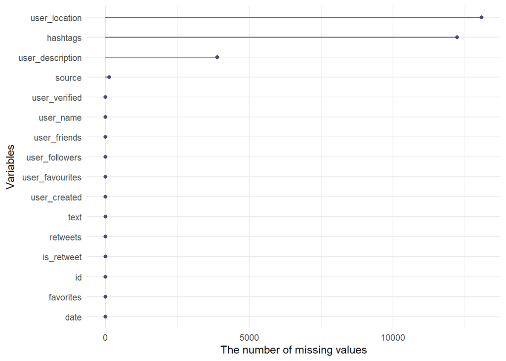

```r
gg_miss_var(testdata) + labs(y = "The number of missing values")
```

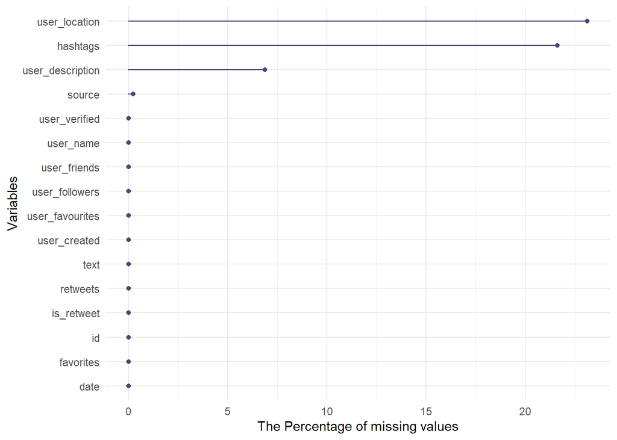

```r
gg_miss_var(testdata, show_pct = TRUE) + labs(y = "The Percentage of missing values")
```

Dropping the **NA** values for getting better and more accurate results.

```r
testdata = na.omit(testdata)

kable(testdata[1:3,], caption = "Dataframe after dropping 'NA")
```

Dataframe after dropping ’NA

|  | id | user_name | user_location | user_description | user_created | user_followers | user_friends | user_favourites | user_verified | date | text | hashtags | source | retweets | favorites | is_retweet |
| --- | --- | --- | --- | --- | --- | --- | --- | --- | --- | --- | --- | --- | --- | --- | --- | --- |
| 1 | 1.340539e+18 | Rachel Roh | La Crescenta-Montrose, CA | Aggregator of Asian American news; scanning diverse sources 24/7/365. RT’s, Follows and ‘Likes’ will fuel me ðŸ‘©‍ðŸ’» | 2009-04-08 17:52:46 | 405 | 1692 | 3247 | False | 2020-12-20 06:06:44 | Same folks said daikon paste could treat a cytokine storm #PfizerBioNTech https://t.co/xeHhIMg1kF | [‘PfizerBioNTech’] | Twitter for Android | 0 | 0 | False |
| 3 | 1.337858e+18 | eliðŸ‡±ðŸ‡¹ðŸ‡ªðŸ‡ºðŸ‘Œ | Your Bed | heil, hydra ðŸ–â˜º | 2020-06-25 23:30:28 | 10 | 88 | 155 | False | 2020-12-12 20:33:45 | #coronavirus #SputnikV #AstraZeneca #PfizerBioNTech #Moderna #Covid_19 Russian vaccine is created to last 2-4 years… https://t.co/ieYlCKBr8P | [‘coronavirus’, ‘SputnikV’, ‘AstraZeneca’, ‘PfizerBioNTech’, ‘Moderna’, ‘Covid_19’] | Twitter for Android | 0 | 0 | False |
| 7 | 1.337851e+18 | Gunther Fehlinger | Austria, Ukraine and Kosovo | End North Stream 2 now - the pipeline of corruption, funding Russias war against Ukraine,Georgia, Syria and political intervention in USA and EU must be stopped | 2013-06-10 17:49:22 | 2731 | 5001 | 69344 | False | 2020-12-12 20:06:00 | it is a bit sad to claim the fame for success of #vaccination on patriotic competition between USA, Canada, UK and… https://t.co/IfMrAyGyTP | [‘vaccination’] | Twitter Web App | 0 | 4 | False |

# Data Visualization:

Let’s try to see whether there’s any correlation between the number of retweets and favorites. Because, in reality, we would assume to have a strong correlation between them.

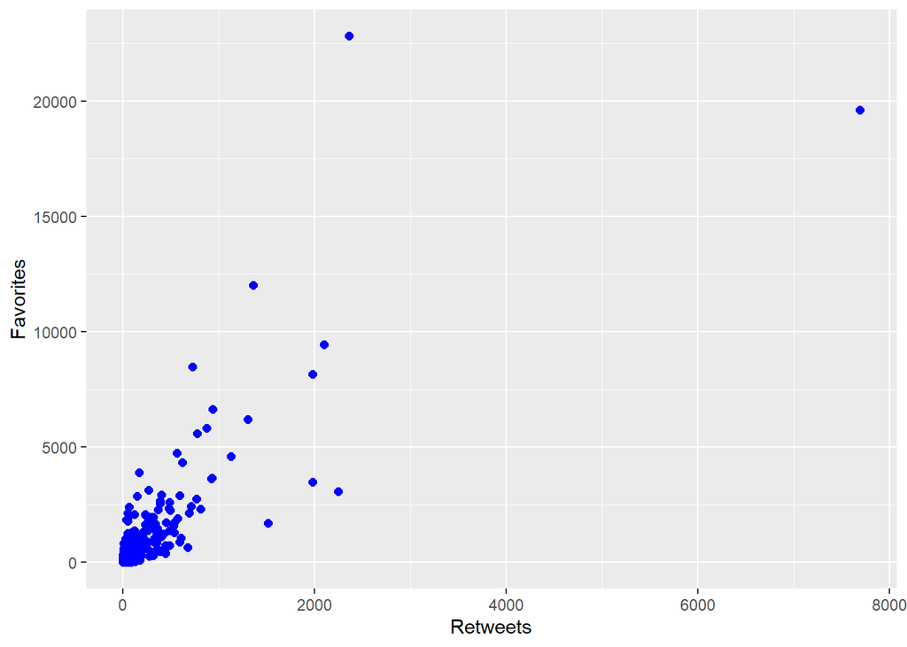

```r
ggplot(testdata, aes(x=retweets, y=favorites)) + geom_point(size=2, color='Blue') +
  labs(x="Retweets", y="Favorites")
```

From the above graph we can observe that there is somewhat strong relation between the retweets and favorites. Lets confrim it with the cor() function.

```r
cor(testdata$retweets, testdata$favorites)
```

```
## [1] 0.8351264
```

Now, Let’s check the correlation between the users followers and retweets

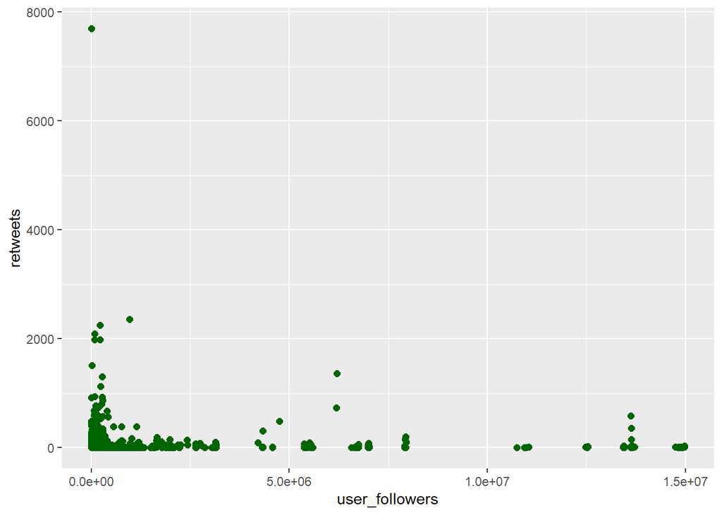

```r
ggplot(testdata, aes(x=user_followers, y=retweets)) + geom_point(size=2, color='Dark green')
```

```r
cor(testdata$user_followers, testdata$retweets)
```

```
## [1] 0.04089292
```

From this, we can conclude that, having more followers and having more retweets have almost no correlation. So there are chances that, the tweets were Retweeted due to some other reasons. Like quality or for having same/relevant hashtags etc.

Now, Let’s check the correlation matrix for all the numerical variables, excluding the id as it has no relevance.

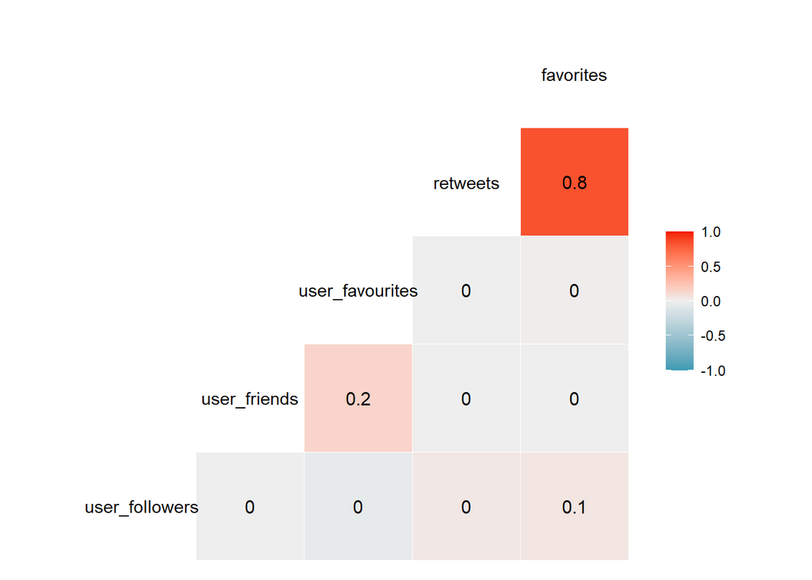

```r
ggcorr(testdata[,-1], palette = "RdGy", label = TRUE)
```

Now, Let’s plot the count of verified and un-verified users

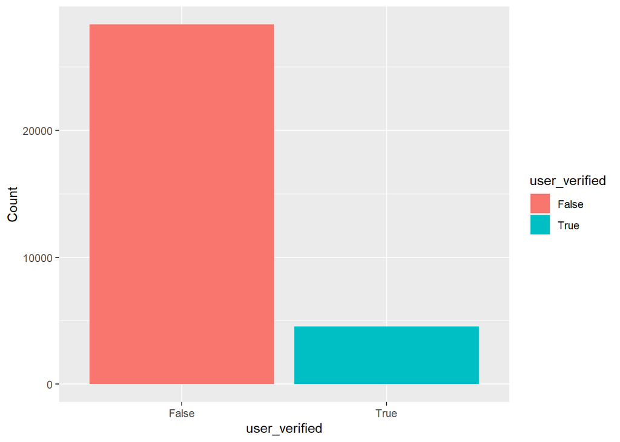

```r
ggplot(testdata, aes(x=user_verified)) + geom_bar(aes(fill=user_verified)) +
  labs(y="Count")
```

As expected. Most users aren’t verified.

Now, Let’s check from which platform (source) the tweets were made. Let’s first check how many total sources are there.

```r
unique(testdata$source)
```

```
##   [1] "Twitter for Android"
##   [2] "Twitter Web App"
##   [3] "Twitter for iPhone"
##   [4] "TweetDeck"
##   [5] "Buffer"
##   [6] "Twitter for iPad"
##   [7] "LinkedIn"
##   [8] "Twitter for Mac"
##   [9] "24liveblog"
##  [10] "SocialFlow"
##  [11] "Instagram"
##  [12] "Socialbakers"
##  [13] "Echobox"
##  [14] "Microsoft Power Platform"
##  [15] "Hootsuite Inc."
```

[output cut: 133 more lines]

Summing all of them in a graph may become tedious and messy. So, for convenience we will analyse the top 10 sources. First let’s store it in a new variable ‘df1’

```r
df1 <- testdata %>%
  group_by(source) %>%
  summarise(count=n()) %>%
  top_n(n=10)
df1
```

```
## # A tibble: 10 x 2
##    source               count
##    <chr>                <int>
##  1 Buffer                 149
##  2 Hootsuite Inc.         356
##  3 IFTTT                   98
##  4 Instagram              665
##  5 TweetDeck             1541
##  6 Twitter for Android   8319
##  7 Twitter for iPad       725
##  8 Twitter for iPhone    9630
##  9 Twitter Media Studio   162
## 10 Twitter Web App      10201
```

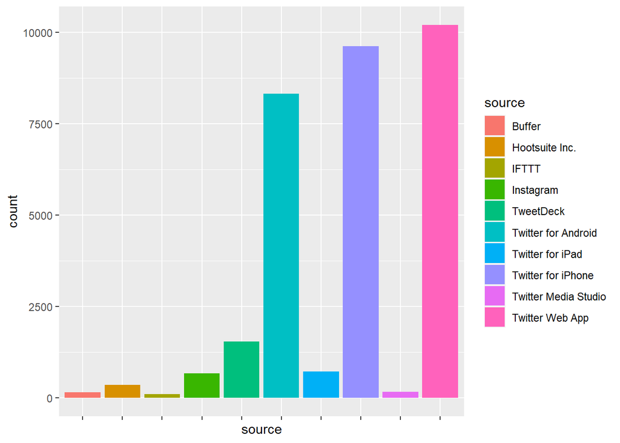

```r
ggplot(data=df1, aes(x=source, y=count)) + geom_bar(aes(fill=source), stat='identity') +
  theme(axis.text.x=element_blank())
```